# Interpreting Log-Log Regression Coefficients

Jared S. Murray

We saw in class and in your reading that if the relationship between some variable $y$ (say quantity sold) and another variable $x$ (say price per unit) was described by the curve

$$y = \alpha x^{\beta_{1}}$$

then ${\beta_{1}}$ was the *elasticity*, which is given by

$${\beta_{1}} = \frac{\partial y}{\partial x}\frac{x}{y} = \frac{\partial y/y}{\partial x/x}$$

At the end of class, I made the claim that ${\beta_{1}}$ is approximately the percentage change in y for a 1% change in $x$. (That is if we are ignore the error terms; if we include them, ${\beta_{1}}$ will be approximately the percentage change of our predicted value of $y$ for a 1% increase in $x$). But why is that? Let $y_0$ be the price when $x = x_0$ and $y_1$ be the price when $x$ increases by 1% (i.e. when $x = 1.01x_0$). The percentange change is given by

$$\begin{align}
100\frac{y_1 - y_0}{y_0} &= 100\frac{\alpha (1.01x)^{\beta_{1}} - \alpha x^{\beta_{1}}}{\alpha x^{\beta_{1}}}\\
&= 100(1.01^{\beta_{1}} - 1)
\end{align}$$

It turns out that $100(1.01^{\beta_{1}} - 1)\approx {\beta_{1}}$ if ${\beta_{1}}$ isn’t too far from zero:

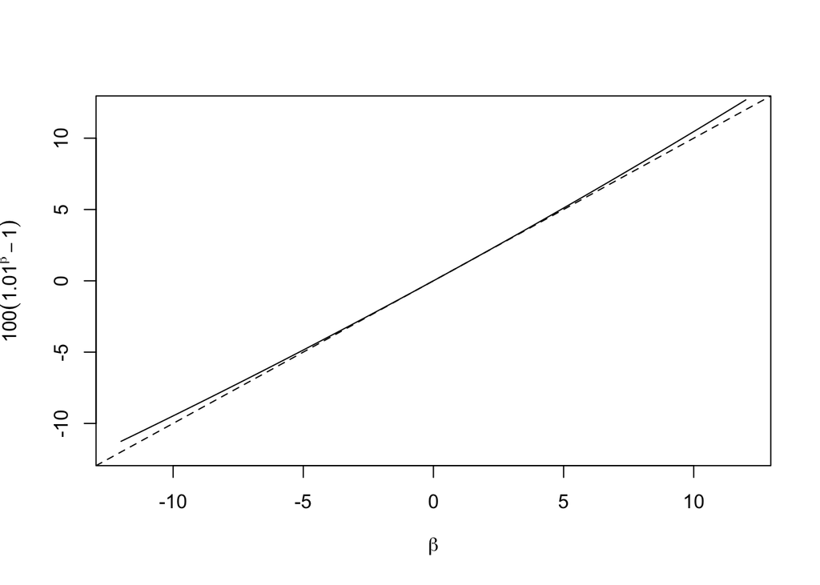

```r
curve(100*(1.01^x-1), from=-12, to=12, xlab=expression(beta), ylab=expression(100(1.01^beta-1)), ylim=c(-12, 12), xlim=c(-12, 12))
abline(0,1, lty=2)
```

Visually, it’s clear that the approximation is very good when ${\beta_{1}}$ is small. We can also plot the error in our approximation:

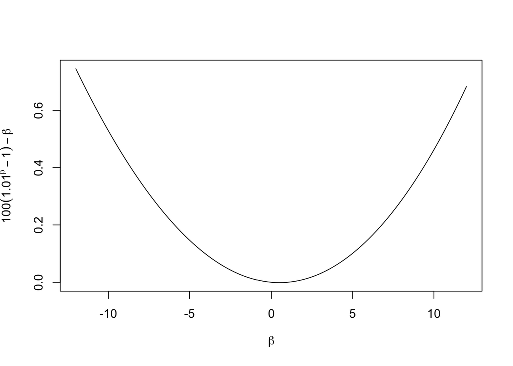

```r
curve(100*(1.01^x-1) - x, from=-12, to=12, xlab=expression(beta), ylab=expression(100(1.01^beta-1) - beta), xlim=c(-12, 12))
```

As long as ${\beta_{1}}$ is relatively small, the error in our approximation is also small. In particular, if ${\beta_{1}}$ is less than about 5 in absolute value, our approximation will understate the true impact of a 1% increase in demand by no more than $\approx 0.15$ percentage points.

(How did I know that $100*(1.01^{\beta_{1}}-1)\approx {\beta_{1}}$ when ${\beta_{1}}$ is small? I took a Taylor expansion of $100*(1.01^{\beta_{1}}-1)$ about ${\beta_{1}}=0$.)